# gold price

Bhanu Kiran

12/01/2022

# Gold price prediction

## Loading libraries

```r
library("readxl")
library(tidyverse)
library(reshape2)
library(caret)
```

Read the dataset

```r
gold_df<- read_excel("complete_data.xlsx")
```

```r
head(gold_df)
```

```
## # A tibble: 6 × 11
##   Date                SENSEX Nifty `S&P` `Oil Price` `USD/INR` `Interest Rate`
##   <dttm>               <dbl> <dbl> <dbl>       <dbl>     <dbl>           <dbl>
## 1 2010-01-04 00:00:00 17559. 5232. 1133.        81.5      46.3            1.98
## 2 2010-01-05 00:00:00 17686. 5278. 1137.        81.7      46.2            1.98
## 3 2010-01-06 00:00:00 17701. 5282. 1137.        83.1      45.7            1.98
## 4 2010-01-07 00:00:00 17616. 5263. 1142.        82.6      45.6            1.98
## 5 2010-01-08 00:00:00 17540. 5245. 1145.        82.7      45.5            1.98
## 6 2010-01-11 00:00:00 17527. 5249. 1147.        82.5      45.3            1.98
## # … with 4 more variables: Gold Demand <dbl>, S&P INR <dbl>,
## #   Oil Price INR <dbl>, Gold Price <dbl>
```

```r
summary(gold_df)
```

```
##       Date                         SENSEX          Nifty            S&P
##  Min.   :2010-01-04 00:00:00   Min.   :15175   Min.   :    0   Min.   :1023
##  1st Qu.:2012-09-28 18:00:00   1st Qu.:19199   1st Qu.: 5746   1st Qu.:1413
##  Median :2015-07-06 12:00:00   Median :26525   Median : 8038   Median :2052
##  Mean   :2015-07-05 17:20:53   Mean   :26787   Mean   : 8020   Mean   :2079
##  3rd Qu.:2018-04-09 18:00:00   3rd Qu.:33686   3rd Qu.:10303   3rd Qu.:2659
##  Max.   :2020-12-31 00:00:00   Max.   :47751   Max.   :14565   Max.   :3756
##    Oil Price         USD/INR      Interest Rate    Gold Demand
##  Min.   : 11.26   Min.   : 0.00   Min.   :1.320   Min.   :3702
##  1st Qu.: 49.76   1st Qu.:54.16   1st Qu.:2.470   1st Qu.:4262
##  Median : 65.96   Median :63.44   Median :5.330   Median :4413
##  Mean   : 69.71   Mean   :60.71   Mean   :4.633   Mean   :4373
##  3rd Qu.: 92.55   3rd Qu.:67.28   3rd Qu.:6.230   3rd Qu.:4504
##  Max.   :113.39   Max.   :77.57   Max.   :7.560   Max.   :4783
##     S&P INR       Oil Price INR      Gold Price
##  Min.   : 75446   Min.   : 830.8   Min.   : 49435
##  1st Qu.:104260   1st Qu.:3671.3   1st Qu.: 75048
##  Median :151374   Median :4866.5   Median : 82246
##  Mean   :153389   Mean   :5143.5   Mean   : 81064
##  3rd Qu.:196156   3rd Qu.:6828.0   3rd Qu.: 88002
##  Max.   :277123   Max.   :8365.9   Max.   :124190
```

```r
str(gold_df)
```

```
## tibble [2,670 × 11] (S3: tbl_df/tbl/data.frame)
##  $ Date         : POSIXct[1:2670], format: "2010-01-04" "2010-01-05" ...
##  $ SENSEX       : num [1:2670] 17559 17686 17701 17616 17540 ...
##  $ Nifty        : num [1:2670] 5232 5278 5282 5263 5245 ...
##  $ S&P          : num [1:2670] 1133 1137 1137 1142 1145 ...
##  $ Oil Price    : num [1:2670] 81.5 81.7 83.1 82.6 82.7 ...
##  $ USD/INR      : num [1:2670] 46.3 46.2 45.7 45.6 45.5 ...
##  $ Interest Rate: num [1:2670] 1.98 1.98 1.98 1.98 1.98 1.98 1.98 1.98 1.98 1.98 ...
##  $ Gold Demand  : num [1:2670] 4194 4194 4194 4194 4194 ...
##  $ S&P INR      : num [1:2670] 83592 83852 83898 84234 84477 ...
##  $ Oil Price INR: num [1:2670] 6015 6031 6133 6094 6105 ...
##  $ Gold Price   : num [1:2670] 50607 51920 51945 51816 51681 ...
```

changing the columns names to all lowercase for easy coding

```r
cols <- c("date", "sensex", "nifty", "snp", "oil_price", "usdinr", "interest_rate", "gold_demand", "snp_inr", "oil_price_inr", "gold_price")
colnames(gold_df) <- cols
```

```r
gold_df$date <- as.character(gold_df$date)
```

we do not need date for correlation, hence making a new dataset

```r
sub_gold <- gold_df %>% select(-date)
```

running a correlation on the dataset

```r
cormat <- round(cor(sub_gold),2)
head(cormat)
```

```
##               sensex nifty   snp oil_price usdinr interest_rate gold_demand
## sensex          1.00  0.94  0.97     -0.67   0.81          0.55       -0.61
## nifty           0.94  1.00  0.92     -0.66   0.77          0.54       -0.57
## snp             0.97  0.92  1.00     -0.67   0.86          0.56       -0.64
## oil_price      -0.67 -0.66 -0.67      1.00  -0.68         -0.52        0.59
## usdinr          0.81  0.77  0.86     -0.68   1.00          0.70       -0.52
## interest_rate   0.55  0.54  0.56     -0.52   0.70          1.00       -0.24
##               snp_inr oil_price_inr gold_price
## sensex           0.97         -0.67       0.55
## nifty            0.92         -0.66       0.51
## snp              1.00         -0.67       0.66
## oil_price       -0.67          1.00      -0.31
## usdinr           0.86         -0.68       0.64
## interest_rate    0.56         -0.52       0.23
```

```r
melted_cormat <- melt(cormat)
head(melted_cormat)
```

```
##            Var1   Var2 value
## 1        sensex sensex  1.00
## 2         nifty sensex  0.94
## 3           snp sensex  0.97
## 4     oil_price sensex -0.67
## 5        usdinr sensex  0.81
## 6 interest_rate sensex  0.55
```

Correlation heatmap

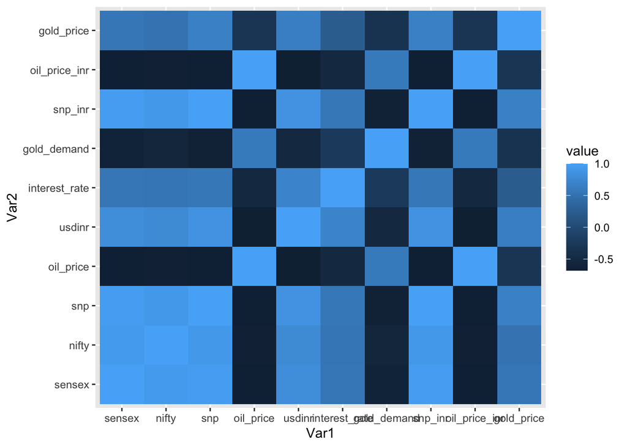

```r
ggplot(data = melted_cormat, aes(x=Var1, y=Var2, fill=value)) +
  geom_tile()
```

From the above graph everything of the value in light_blue is positive correlated and everything in navy blue is inversely correlated

## Modelling a linear regression

Exclude the snp and oil_price columns because we take the snp_inr and oil_price_inr as the converted prices

```r
mylog <- lm(gold_df$gold_price ~ gold_df$sensex + gold_df$nifty + gold_df$usdinr + gold_df$interest_rate + gold_df$gold_demand + gold_df$snp_inr + gold_df$oil_price_inr)
```

```r
summary(mylog)
```

```
##
## Call:
## lm(formula = gold_df$gold_price ~ gold_df$sensex + gold_df$nifty +
##     gold_df$usdinr + gold_df$interest_rate + gold_df$gold_demand +
##     gold_df$snp_inr + gold_df$oil_price_inr)
##
## Residuals:
##    Min     1Q Median     3Q    Max
## -17293  -5073    -88   4607  41254
##
## Coefficients:
##                         Estimate Std. Error t value Pr(>|t|)
## (Intercept)            3.631e+03  3.623e+03   1.002  0.31634
## gold_df$sensex        -2.124e+00  9.255e-02 -22.952  < 2e-16 ***
## gold_df$nifty         -5.103e-01  1.716e-01  -2.975  0.00296 **
## gold_df$usdinr         5.408e+02  3.741e+01  14.456  < 2e-16 ***
## gold_df$interest_rate -2.011e+03  1.069e+02 -18.813  < 2e-16 ***
## gold_df$gold_demand    6.458e+00  7.247e-01   8.911  < 2e-16 ***
## gold_df$snp_inr        5.261e-01  1.523e-02  34.545  < 2e-16 ***
## gold_df$oil_price_inr  1.162e+00  1.254e-01   9.265  < 2e-16 ***
## ---
## Signif. codes:  0 '***' 0.001 '**' 0.01 '*' 0.05 '.' 0.1 ' ' 1
##
## Residual standard error: 7239 on 2662 degrees of freedom
## Multiple R-squared:  0.6775, Adjusted R-squared:  0.6766
## F-statistic: 798.8 on 7 and 2662 DF,  p-value: < 2.2e-16
```

3 statistics to check for goodness of fit 1. p-value => 2.2e-16 which is a very tiny number. This indicates that the values are significant  
2. F-statistic => 798.8 with 2662 degrees of freedom 3. R-squared => 0.7 this is way above 0.5 which indicates a good model

plots of the model

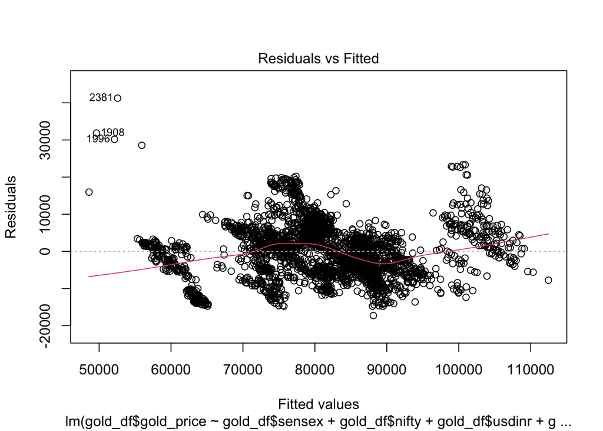

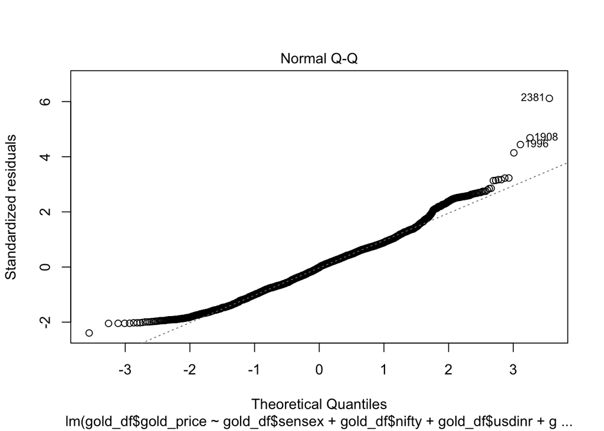

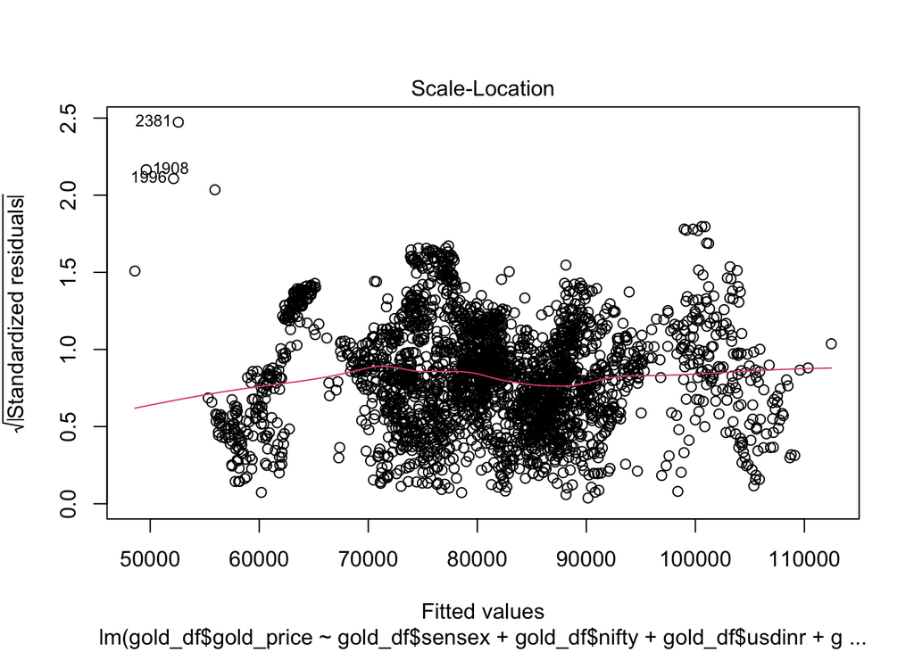

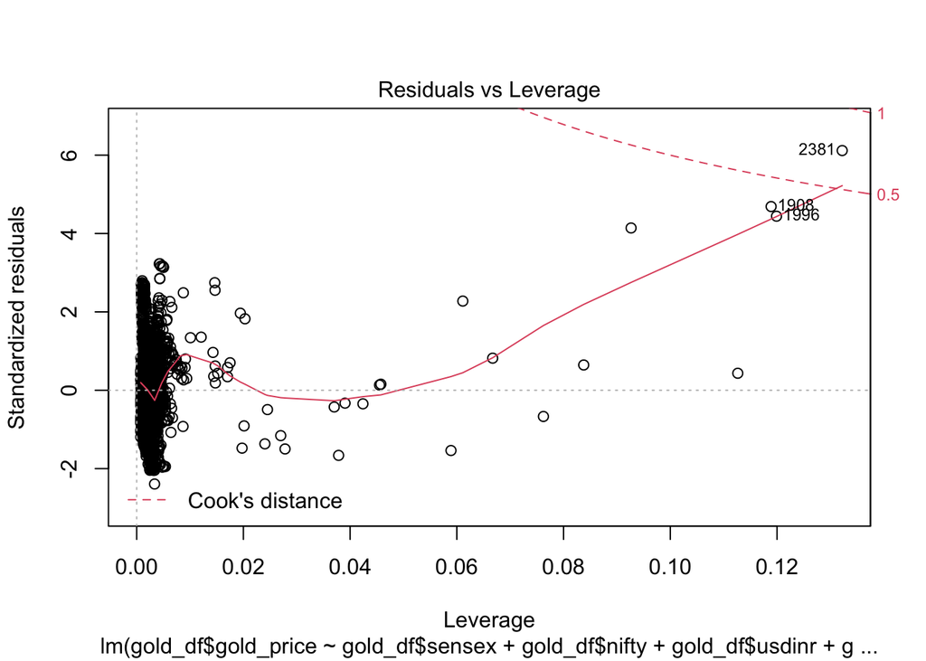

```r
plot(mylog)
```

## Modelling a Linear regression with feature combinations

Regression model without snp_inr and oil_price_inr

```r
mylog_1 <- lm(gold_df$gold_price ~ gold_df$sensex + gold_df$nifty + gold_df$usdinr + gold_df$interest_rate + gold_df$gold_demand)
```

```r
summary(mylog_1)
```

```
##
## Call:
## lm(formula = gold_df$gold_price ~ gold_df$sensex + gold_df$nifty +
##     gold_df$usdinr + gold_df$interest_rate + gold_df$gold_demand)
##
## Residuals:
##    Min     1Q Median     3Q    Max
## -19012  -5381  -1172   5356  86462
##
## Coefficients:
##                         Estimate Std. Error t value Pr(>|t|)
## (Intercept)           -2.611e+03  4.452e+03  -0.587    0.557
## gold_df$sensex         3.119e-01  7.396e-02   4.216 2.57e-05 ***
## gold_df$nifty         -3.358e-01  2.097e-01  -1.601    0.109
## gold_df$usdinr         1.208e+03  3.707e+01  32.589  < 2e-16 ***
## gold_df$interest_rate -2.920e+03  1.278e+02 -22.842  < 2e-16 ***
## gold_df$gold_demand    4.161e+00  8.207e-01   5.070 4.26e-07 ***
## ---
## Signif. codes:  0 '***' 0.001 '**' 0.01 '*' 0.05 '.' 0.1 ' ' 1
##
## Residual standard error: 8924 on 2664 degrees of freedom
## Multiple R-squared:  0.5095, Adjusted R-squared:  0.5086
## F-statistic: 553.4 on 5 and 2664 DF,  p-value: < 2.2e-16
```

The multiple R squared is 0.50 which is no better that with all the features which is 0.67

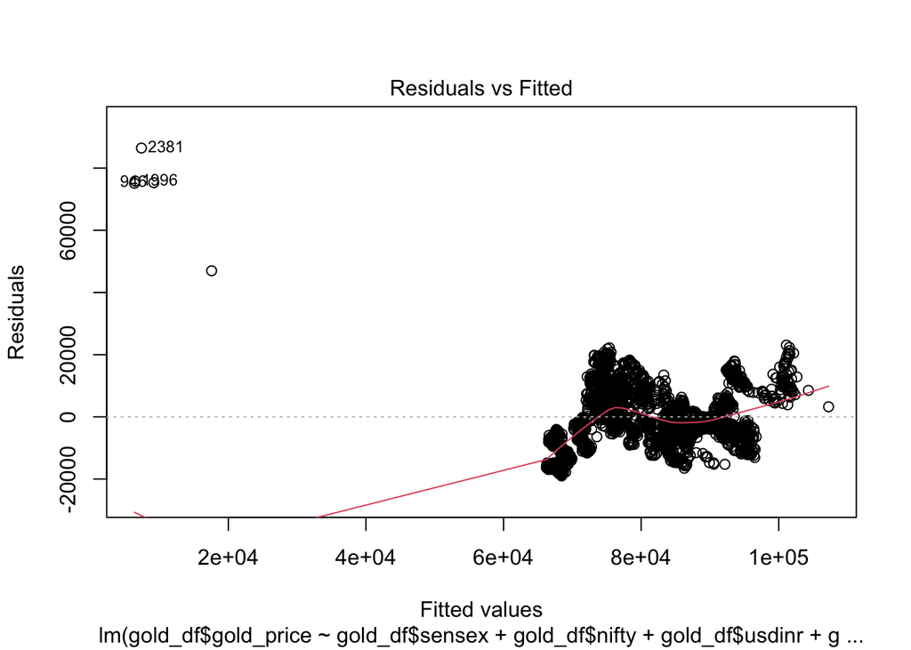

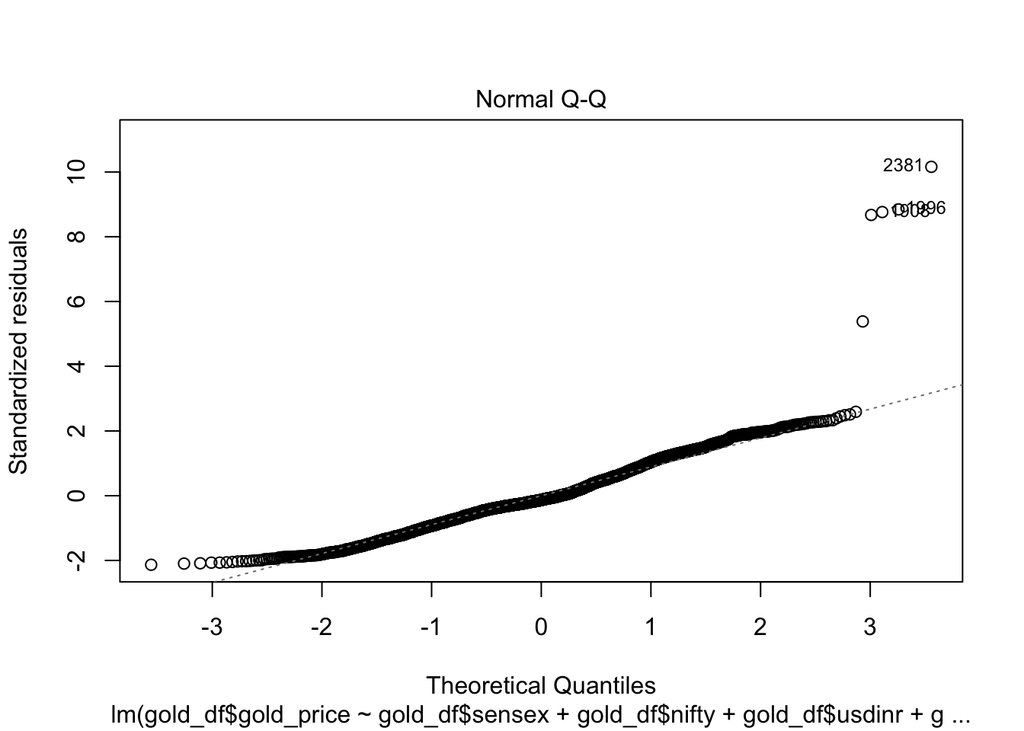

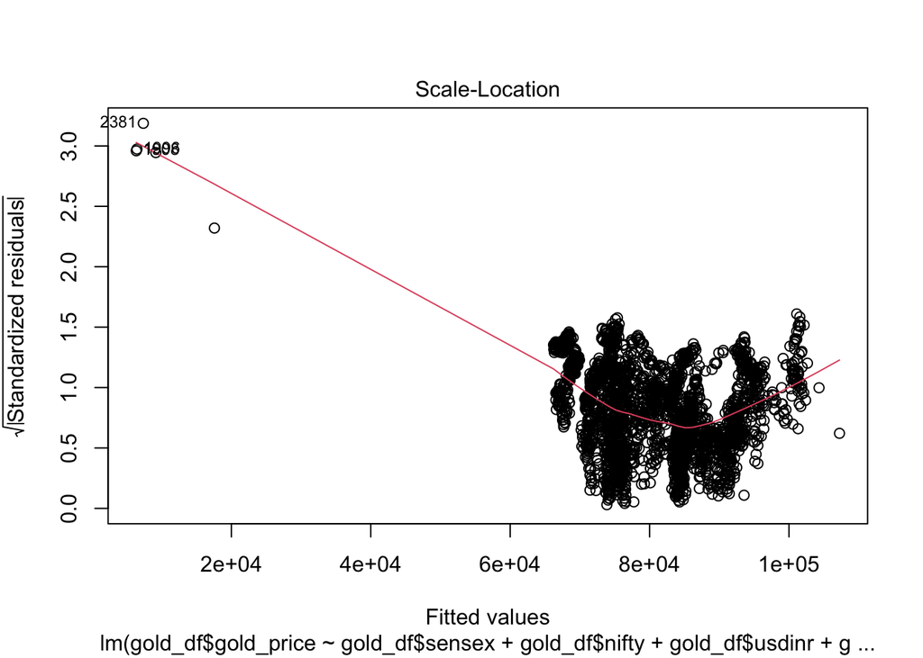

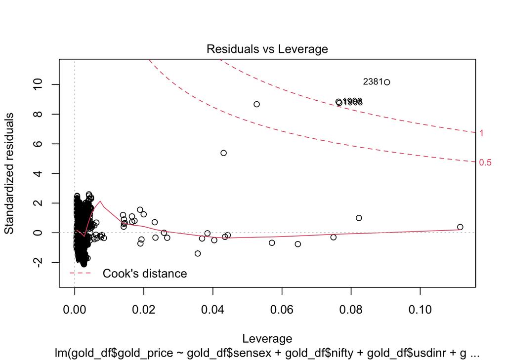

```r
plot(mylog_1)
```

Regression Model with only snp_inr and oil_price_inr

```r
mylog_2 <- lm(gold_df$gold_price ~ gold_df$oil_price_inr + gold_df$snp_inr)
```

```r
summary(mylog_2)
```

```
##
## Call:
## lm(formula = gold_df$gold_price ~ gold_df$oil_price_inr + gold_df$snp_inr)
##
## Residuals:
##    Min     1Q Median     3Q    Max
## -19737  -6487  -2555   7211  23614
##
## Coefficients:
##                        Estimate Std. Error t value Pr(>|t|)
## (Intercept)           3.863e+04  1.350e+03   28.61   <2e-16 ***
## gold_df$oil_price_inr 1.899e+00  1.408e-01   13.48   <2e-16 ***
## gold_df$snp_inr       2.129e-01  4.821e-03   44.17   <2e-16 ***
## ---
## Signif. codes:  0 '***' 0.001 '**' 0.01 '*' 0.05 '.' 0.1 ' ' 1
##
## Residual standard error: 9211 on 2667 degrees of freedom
## Multiple R-squared:  0.4768, Adjusted R-squared:  0.4764
## F-statistic:  1215 on 2 and 2667 DF,  p-value: < 2.2e-16
```

This is even lower than model without snp_inr and oil_price_inr and model with all the features

Model with without gold_demand

```r
mylog_3 <- lm(gold_df$gold_price ~ gold_df$sensex + gold_df$nifty + gold_df$usdinr + gold_df$interest_rate + gold_df$snp_inr + gold_df$oil_price_inr)
```

```r
summary(mylog_3)
```

```
##
## Call:
## lm(formula = gold_df$gold_price ~ gold_df$sensex + gold_df$nifty +
##     gold_df$usdinr + gold_df$interest_rate + gold_df$snp_inr +
##     gold_df$oil_price_inr)
##
## Residuals:
##    Min     1Q Median     3Q    Max
## -17803  -4850   -441   4490  43612
##
## Coefficients:
##                         Estimate Std. Error t value Pr(>|t|)
## (Intercept)            3.079e+04  1.989e+03  15.477   <2e-16 ***
## gold_df$sensex        -2.095e+00  9.384e-02 -22.325   <2e-16 ***
## gold_df$nifty         -4.006e-01  1.736e-01  -2.307   0.0211 *
## gold_df$usdinr         5.596e+02  3.790e+01  14.766   <2e-16 ***
## gold_df$interest_rate -1.818e+03  1.062e+02 -17.115   <2e-16 ***
## gold_df$snp_inr        4.959e-01  1.506e-02  32.918   <2e-16 ***
## gold_df$oil_price_inr  1.556e+00  1.191e-01  13.065   <2e-16 ***
## ---
## Signif. codes:  0 '***' 0.001 '**' 0.01 '*' 0.05 '.' 0.1 ' ' 1
##
## Residual standard error: 7345 on 2663 degrees of freedom
## Multiple R-squared:  0.6679, Adjusted R-squared:  0.6671
## F-statistic: 892.4 on 6 and 2663 DF,  p-value: < 2.2e-16
```

Close to the original model with r squared 0.66

Model without sensex and nifty

```r
mylog_4 <- lm(gold_df$gold_price ~ gold_df$usdinr + gold_df$interest_rate + gold_df$gold_demand + gold_df$snp_inr + gold_df$oil_price_inr)
```

```r
summary(mylog_4)
```

```
##
## Call:
## lm(formula = gold_df$gold_price ~ gold_df$usdinr + gold_df$interest_rate +
##     gold_df$gold_demand + gold_df$snp_inr + gold_df$oil_price_inr)
##
## Residuals:
##    Min     1Q Median     3Q    Max
## -16112  -6120  -1126   5101  62030
##
## Coefficients:
##                         Estimate Std. Error t value Pr(>|t|)
## (Intercept)           -1.283e+04  4.066e+03  -3.154  0.00163 **
## gold_df$usdinr         9.052e+02  3.990e+01  22.686  < 2e-16 ***
## gold_df$interest_rate -2.544e+03  1.197e+02 -21.254  < 2e-16 ***
## gold_df$gold_demand    4.682e+00  8.197e-01   5.712 1.24e-08 ***
## gold_df$snp_inr        1.361e-01  7.047e-03  19.307  < 2e-16 ***
## gold_df$oil_price_inr  1.822e+00  1.395e-01  13.067  < 2e-16 ***
## ---
## Signif. codes:  0 '***' 0.001 '**' 0.01 '*' 0.05 '.' 0.1 ' ' 1
##
## Residual standard error: 8236 on 2664 degrees of freedom
## Multiple R-squared:  0.5822, Adjusted R-squared:  0.5814
## F-statistic: 742.4 on 5 and 2664 DF,  p-value: < 2.2e-16
```

From the trails we find that taking out two features has lower r square value. But we want it to be of a high number above 0.5

Model with only positive correlation values (excluding oil_price_inr and gold_demand)

```r
mylogPossitive <- lm(gold_df$gold_price ~ gold_df$sensex + gold_df$nifty + gold_df$usdinr + gold_df$interest_rate + gold_df$snp_inr )
```

```r
summary(mylogPossitive)
```

```
##
## Call:
## lm(formula = gold_df$gold_price ~ gold_df$sensex + gold_df$nifty +
##     gold_df$usdinr + gold_df$interest_rate + gold_df$snp_inr)
##
## Residuals:
##    Min     1Q Median     3Q    Max
## -18417  -5056   -501   4688  37586
##
## Coefficients:
##                         Estimate Std. Error t value Pr(>|t|)
## (Intercept)            4.881e+04  1.478e+03  33.024  < 2e-16 ***
## gold_df$sensex        -2.207e+00  9.638e-02 -22.903  < 2e-16 ***
## gold_df$nifty         -6.210e-01  1.782e-01  -3.484 0.000501 ***
## gold_df$usdinr         4.524e+02  3.816e+01  11.856  < 2e-16 ***
## gold_df$interest_rate -1.918e+03  1.093e+02 -17.555  < 2e-16 ***
## gold_df$snp_inr        5.071e-01  1.551e-02  32.695  < 2e-16 ***
## ---
## Signif. codes:  0 '***' 0.001 '**' 0.01 '*' 0.05 '.' 0.1 ' ' 1
##
## Residual standard error: 7575 on 2664 degrees of freedom
## Multiple R-squared:  0.6466, Adjusted R-squared:  0.6459
## F-statistic: 974.7 on 5 and 2664 DF,  p-value: < 2.2e-16
```

This has significant impact on the model. as from the trails if we take off two features the r squared is decreasing. but if we take onyl possitive correlation we get a good result.

Model with negative correlations

```r
mylogNegative <- lm(gold_df$gold_price ~  gold_df$gold_demand + gold_df$oil_price_inr)
```

```r
summary(mylogNegative)
```

```
##
## Call:
## lm(formula = gold_df$gold_price ~ gold_df$gold_demand + gold_df$oil_price_inr)
##
## Residuals:
##    Min     1Q Median     3Q    Max
## -33366  -6646   1180   7547  32433
##
## Coefficients:
##                         Estimate Std. Error t value Pr(>|t|)
## (Intercept)            1.405e+05  4.096e+03  34.298  < 2e-16 ***
## gold_df$gold_demand   -1.226e+01  1.037e+00 -11.824  < 2e-16 ***
## gold_df$oil_price_inr -1.127e+00  1.656e-01  -6.807 1.23e-11 ***
## ---
## Signif. codes:  0 '***' 0.001 '**' 0.01 '*' 0.05 '.' 0.1 ' ' 1
##
## Residual standard error: 11810 on 2667 degrees of freedom
## Multiple R-squared:  0.1392, Adjusted R-squared:  0.1386
## F-statistic: 215.7 on 2 and 2667 DF,  p-value: < 2.2e-16
```

0.13, a very bad model.

## Extra work

```r
samples <- gold_df$gold_price %>% createDataPartition(p=0.8, list = FALSE)
train.data <- gold_df[samples,]
test.data <- gold_df[-samples,]
```

```r
colnames(gold_df)
```

```
##  [1] "date"          "sensex"        "nifty"         "snp"
##  [5] "oil_price"     "usdinr"        "interest_rate" "gold_demand"
##  [9] "snp_inr"       "oil_price_inr" "gold_price"
```

```r
model <- lm(gold_price ~ sensex + nifty + usdinr+ interest_rate+ gold_demand+ snp_inr+ oil_price_inr+ gold_price ,data= train.data)
summary(model)
```

```
##
## Call:
## lm(formula = gold_price ~ sensex + nifty + usdinr + interest_rate +
##     gold_demand + snp_inr + oil_price_inr + gold_price, data = train.data)
##
## Residuals:
##    Min     1Q Median     3Q    Max
## -17031  -5058    -73   4586  37254
##
## Coefficients:
##                 Estimate Std. Error t value Pr(>|t|)
## (Intercept)    4.353e+03  4.025e+03   1.082  0.27959
## sensex        -2.193e+00  1.030e-01 -21.288  < 2e-16 ***
## nifty         -4.940e-01  1.813e-01  -2.725  0.00649 **
## usdinr         4.843e+02  3.942e+01  12.286  < 2e-16 ***
## interest_rate -1.956e+03  1.177e+02 -16.621  < 2e-16 ***
## gold_demand    6.792e+00  8.132e-01   8.352  < 2e-16 ***
## snp_inr        5.444e-01  1.674e-02  32.521  < 2e-16 ***
## oil_price_inr  1.150e+00  1.401e-01   8.205 3.95e-16 ***
## ---
## Signif. codes:  0 '***' 0.001 '**' 0.01 '*' 0.05 '.' 0.1 ' ' 1
##
## Residual standard error: 7243 on 2130 degrees of freedom
## Multiple R-squared:  0.6794, Adjusted R-squared:  0.6784
## F-statistic: 644.9 on 7 and 2130 DF,  p-value: < 2.2e-16
```

```r
predictions <- model %>% predict(test.data)
RMSE(predictions, test.data$gold_price)
```

```
## [1] 7243.515
```

```r
R2(predictions, test.data$gold_price)
```

```
## [1] 0.6678071
```

```r
my_preds <- data.frame(test.data$date, predictions)
```

```r
(my_preds)
```

```
##     test.data.date predictions
## 1       2010-01-07    62704.82
## 2       2010-01-21    62586.23
## 3       2010-01-25    62394.11
## 4       2010-02-01    63080.48
## 5       2010-02-02    64337.54
## 6       2010-02-04    62287.00
## 7       2010-02-08    63052.24
## 8       2010-02-09    63208.38
## 9       2010-02-18    64366.45
## 10      2010-03-08    63653.81
## 11      2010-03-12    63884.58
## 12      2010-03-31    63582.81
## 13      2010-04-01    63655.39
## 14      2010-04-05    63342.43
```

[output cut: 518 more lines]

## Model Interpretation

From our model, before we make our predictions let’s have a look at the goodness of fit.

on the predictions below we technically use the formula:

Y= B0 + B1x1 + B2x2 … + Bnxn + e

where e is the error value which is +/- in nature

Therefore the regression formula for predicting the gold prices is:

Y = 3.631e+03 + (-2.124e+00 x sensex) + (-5.103e-01 x nifty) + (5.408e+02 x usdinr)  
+ (-2.011e+03 x interest rate) + (6.458e+00 x gold demand) + (5.261e-01 x s&p inr) + (1.162e+00 x oil price inr) +- 7239